# Predicting Exercise Behavior from Wearable Devices Data

Asem Radhwi

Wednesday, October 22, 2014

### Objective

The objective of this machine learning exercise is to predict the classification of the exercise from the data provided from the sensors in: http://groupware.les.inf.puc-rio.br/har

### Loading Required Libraries

```r
library(caret)
library(ggplot2)
library(randomForest)
library(rattle)
```

### Data Loading and Cleaning

First, we read in the raw data. After looking at the data, we remove the NA columns, and the first seven columns as they are extra, and non-required in our prediction.

```r
#Read raw data in
rawData <- read.csv('pml-training.csv', header = TRUE, na.strings=c("NA",""))

#Remove extra columns
data <- rawData[,-1:-7]

#Remove bad columns
naTest <- sapply(data, function(x){sum(is.na(x))})
table(naTest)
```

```
## naTest
##     0 19216
##    53   100
```

```r
badColumns <- names(naTest[naTest!=0])
data = data[, !names(data) %in% badColumns]
```

Now, there are 19622 rows with 53 variables. The predicted variable is classe, and the levels are 5 classes. The data will be splitted into training (70%) and testing (30%) datasets to build our models.

```r
table(data$classe)
```

```
##
##    A    B    C    D    E
## 5580 3797 3422 3216 3607
```

```r
set.seed(3333)
inTrain <- createDataPartition(y=data$classe, p=0.7, list=FALSE)
training <- data[inTrain,]
testing <- data[-inTrain,]
```

We see that the dimensions of the training and the testing match up the original dataset.

```r
dim(training)
```

```
## [1] 13737    53
```

```r
dim(testing)
```

```
## [1] 5885   53
```

```r
dim(training)[1] + dim(testing)[1] == dim(data)[1]
```

```
## [1] TRUE
```

```r
dim(training)[2]==dim(data)[2]
```

```
## [1] TRUE
```

```r
dim(testing)[2]==dim(data)[2]
```

```
## [1] TRUE
```

### Building the Model

I have experimented with many prediction algorithms: rpart, rf, boosting, svm, gbm, lda, and lasso. Fortunately, although time-consuming, I chose the Random Forest prediction algorithm here because they don’t overfit with many input variables like the others. Check more from here: https://www.stat.berkeley.edu/~breiman/RandomForests/cc_home.htm

```r
##Run for an hour, then save the model for later reuse.
#modFitRF <- train(classe ~ ., data=training, method="rf", prox=TRUE)
#saveRDS('modFitRF.rds')

#Fetch previously saved model
modFitRF <- readRDS('modFitRF.rds')
modFitRF
```

```
## Random Forest
##
## 13737 samples
##    52 predictor
##     5 classes: 'A', 'B', 'C', 'D', 'E'
##
## No pre-processing
## Resampling: Bootstrapped (25 reps)
##
## Summary of sample sizes: 13737, 13737, 13737, 13737, 13737, 13737, ...
##
## Resampling results across tuning parameters:
##
##   mtry  Accuracy  Kappa  Accuracy SD  Kappa SD
##    2    1         1      0.002        0.003
##   27    1         1      0.002        0.003
##   52    1         1      0.004        0.005
##
## Accuracy was used to select the optimal model using  the largest value.
## The final value used for the model was mtry = 27.
```

### Model Evaluation

```r
#Run the predictions on the testing dataset
predictionsRF <- predict(modFitRF, newdata=testing)

#Error Rate
sum(predictionsRF!=testing$classe)/length(testing$classe)
```

```
## [1] 0.006967
```

```r
RFA <- confusionMatrix(predictionsRF, testing$classe)
RFA
```

```
## Confusion Matrix and Statistics
##
##           Reference
## Prediction    A    B    C    D    E
##          A 1673    4    0    0    0
##          B    1 1132   11    0    1
##          C    0    3 1008   12    0
##          D    0    0    7  952    2
##          E    0    0    0    0 1079
##
## Overall Statistics
##
##                Accuracy : 0.993
##                  95% CI : (0.991, 0.995)
##     No Information Rate : 0.284
##     P-Value [Acc > NIR] : <2e-16
##
##                   Kappa : 0.991
##  Mcnemar's Test P-Value : NA
##
## Statistics by Class:
##
##                      Class: A Class: B Class: C Class: D Class: E
## Sensitivity             0.999    0.994    0.982    0.988    0.997
## Specificity             0.999    0.997    0.997    0.998    1.000
## Pos Pred Value          0.998    0.989    0.985    0.991    1.000
## Neg Pred Value          1.000    0.999    0.996    0.998    0.999
## Prevalence              0.284    0.194    0.174    0.164    0.184
## Detection Rate          0.284    0.192    0.171    0.162    0.183
## Detection Prevalence    0.285    0.195    0.174    0.163    0.183
## Balanced Accuracy       0.999    0.996    0.990    0.993    0.999
```

### Variable Importance

We can see that the roll_belt is the most imortant variable in the dataset.

```r
imp <- varImp(modFitRF)$importance
imp
```

```
##                       Overall
## roll_belt            100.0000
## pitch_belt            43.1520
## yaw_belt              54.4004
## total_accel_belt       1.6832
## gyros_belt_x           1.3956
## gyros_belt_y           1.7695
## gyros_belt_z          11.0925
## accel_belt_x           0.7573
## accel_belt_y           0.8660
## accel_belt_z          12.8444
## magnet_belt_x         10.3387
## magnet_belt_y         11.6793
## magnet_belt_z         15.5493
## roll_arm               8.7203
## pitch_arm              5.0001
## yaw_arm               10.5671
## total_accel_arm        1.7004
## gyros_arm_x            2.4174
## gyros_arm_y            3.8658
## gyros_arm_z            0.0000
## accel_arm_x            8.0327
## accel_arm_y            2.7714
## accel_arm_z            2.2947
## magnet_arm_x           5.2947
## magnet_arm_y           6.0267
## magnet_arm_z           4.4418
## roll_dumbbell         17.1257
## pitch_dumbbell         3.5141
## yaw_dumbbell           8.2705
## total_accel_dumbbell  13.8009
## gyros_dumbbell_x       2.9141
## gyros_dumbbell_y       6.4760
## gyros_dumbbell_z       1.0954
## accel_dumbbell_x       6.1813
## accel_dumbbell_y      22.5633
## accel_dumbbell_z      14.1101
## magnet_dumbbell_x     17.9215
## magnet_dumbbell_y     41.0058
## magnet_dumbbell_z     42.4439
## roll_forearm          42.5148
## pitch_forearm         58.9041
## yaw_forearm            5.3682
## total_accel_forearm    1.0662
## gyros_forearm_x        0.1542
## gyros_forearm_y        2.4718
## gyros_forearm_z        1.0731
## accel_forearm_x       17.4553
## accel_forearm_y        3.1349
## accel_forearm_z        8.2310
## magnet_forearm_x       6.2329
## magnet_forearm_y       7.0846
## magnet_forearm_z      13.0980
```

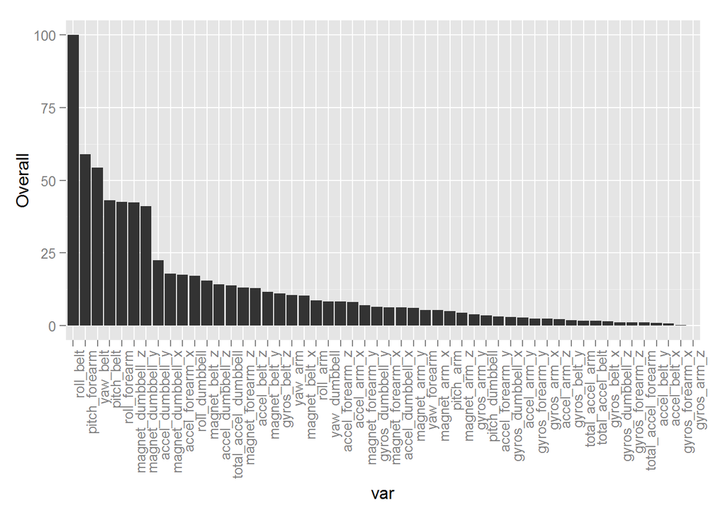

```r
imp$var <- reorder(row.names(imp), -imp$Overall)
ggplot(data=imp, aes(x=var, y=Overall)) + geom_bar(stat="identity") + theme(axis.text.x = element_text(angle = 90, hjust = 1))
```

### Run Model on Hidden Testing Dataset

The model ran on the testing dataset given in pml-testing.csv. The results when submitted were 100% accurate.

```r
pml_write_files = function(x){
  n = length(x)
  for(i in 1:n){
    filename = paste0("problem_id_",i,".txt")
    write.table(x[i],file=filename,quote=FALSE,row.names=FALSE,col.names=FALSE)
  }
}

rawTesting <- read.csv('pml-testing.csv', header = TRUE, na.strings=c("NA",""))
dataTesting <- rawTesting[,-1:-7]
dataTesting = dataTesting[, !names(dataTesting) %in% badColumns]


predictionsRF <- predict(modFitRF, newdata=dataTesting)
pml_write_files(predictionsRF)
```

### Conclusions

Random Forests proved to be very accurate in this exercise. I have not experimented with pre-processing techniques because I felt the accuracy without them to be very high.